# Reproducible Research Course Project 1

## By John S. Budd

### Loading and preprocessing the data

The first component of this analysis focuses on unzipping the ‘activity.zip’ file and reading the dataset into R, creating a dataframe called ‘active_set’ to support answering the questions that follow.

```r
## Gets the file from the url and unzips it to the working directory
url <- "https://d396qusza40orc.cloudfront.net/repdata%2Fdata%2Factivity.zip"
temp <- tempfile()
download.file(url, temp)
Unzipdir <- unzip(temp)
## Creates a dataframe using the read.csv of the activity file
active_set <- read.csv("activity.csv")
## Converts the dates into a date format
active_set$date <- as.Date(active_set$date)
```

### What is the mean total number of steps taken per day?

During this next code chunk, the code will do the following:

1. Calculate the total number of steps taken per day The code chunk below loads the dplyr package and calculates thessteps taken per day

```r
## loads the dplyr package
library(dplyr)
## finds the sum of each day
sum_set <- active_set %>%
  group_by(date) %>%
  summarise(steps = sum(steps))
```

2. Make a histogram of the total number of steps taken each day

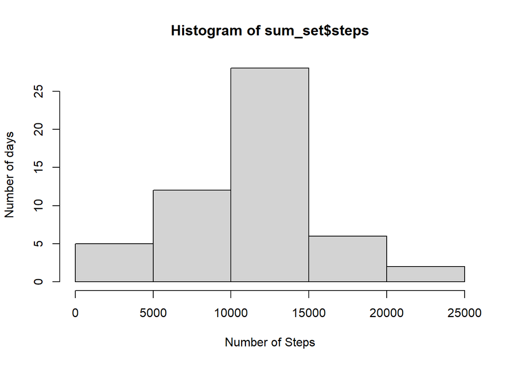

```r
hist(sum_set$steps, xlab = "Number of Steps", ylab = "Number of days")
```

3. Calculate and report the mean and median of the total number of steps taken per day

```r
## Finds the mean, ignoring NAs
mean(sum_set$steps, na.rm = TRUE)
```

```
## [1] 10766.19
```

```r
## Finds the median, ignoring NAs
median(sum_set$steps, na.rm = TRUE)
```

```
## [1] 10765
```

### What is the average daily activity pattern?

During this next code chunk, the code will do the following

1. Make a time series plot (i.e. type = “l”) of the 5-minute interval (x-axis) and the average number of steps taken averaged across all days (y-axis)

```r
## creates a tibble with the average of each five minute interval ignoring NAs
avg_set <- active_set %>%
  group_by(interval) %>%
  summarise(steps = mean(steps, na.rm = TRUE))
```

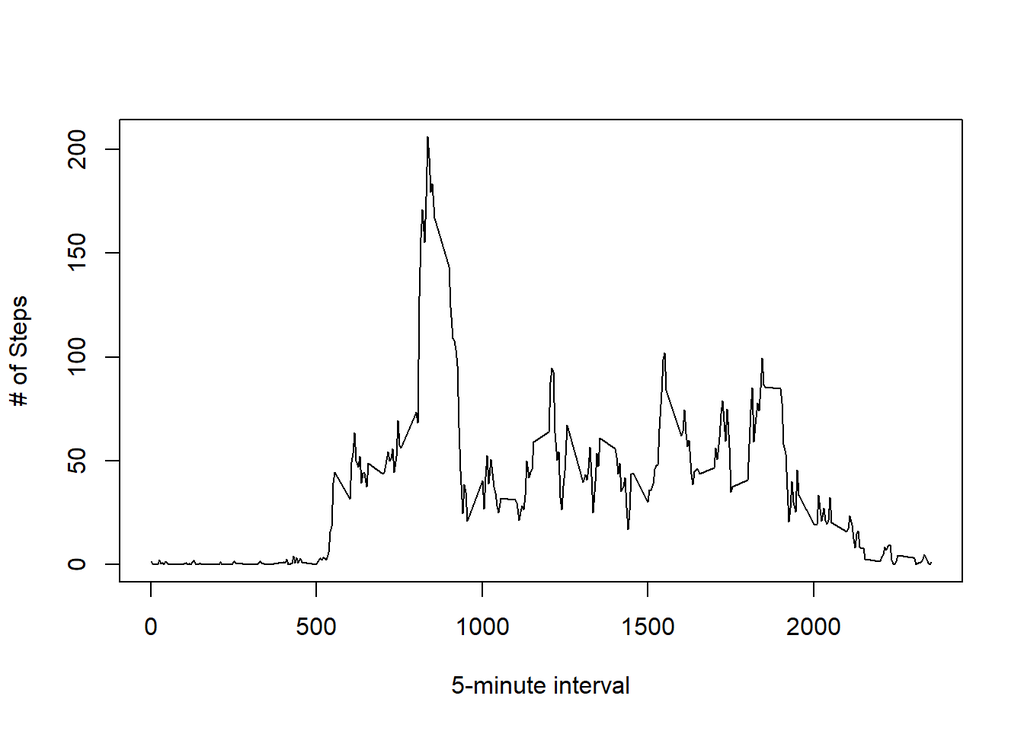

```r
## plots the avg_set
plot(avg_set$interval,avg_set$steps, type = "l", xlab = "5-minute interval",
     ylab = "# of Steps")
```

2. Which 5-minute interval, on average across all days in the dataset, contains the maximum number of steps?

```r
avg_set[which.max(avg_set$steps),]
```

```
## # A tibble: 1 x 2
##   interval steps
##      <int> <dbl>
## 1      835  206.
```

### Imputing missing values

During this next code chunk, the code will do the following:

1. Calculate and report the total number of missing values in the dataset (i.e. the total number of rows with NAs)

```r
## provides an overall summary of the dataset including the number of NAs
summary(active_set)
```

```
##      steps             date               interval
##  Min.   :  0.00   Min.   :2012-10-01   Min.   :   0.0
##  1st Qu.:  0.00   1st Qu.:2012-10-16   1st Qu.: 588.8
##  Median :  0.00   Median :2012-10-31   Median :1177.5
##  Mean   : 37.38   Mean   :2012-10-31   Mean   :1177.5
##  3rd Qu.: 12.00   3rd Qu.:2012-11-15   3rd Qu.:1766.2
##  Max.   :806.00   Max.   :2012-11-30   Max.   :2355.0
##  NA's   :2304
```

2. Devise a strategy for filling in all of the missing values in the dataset. The strategy does not need to be sophisticated. For example, you could use the mean/median for that day, or the mean for that 5-minute interval, etc.
3. Create a new dataset that is equal to the original dataset but with the missing data filled in

The code chunk below addresses both questions above:

```r
## finds the mean for each interval
avg_set <- active_set %>%
  group_by(interval) %>%
  summarise(steps = mean(steps, na.rm = TRUE))
## uses the transform function to identify areas where there is NA in the
## active_set and replaces it with the average for the five-minute interval
## and creates a new_imputeset

new_imputeset <- transform(active_set,
                              steps = ifelse(is.na(active_set$steps),
                                             avg_set$steps[match(active_set$interval, x =  avg_set$interval)],
                                             active_set$steps))
```

4. Make a histogram of the total number of steps taken each day:

```r
## finds the sum of each day
impsum_set <- new_imputeset %>%
  group_by(date) %>%
  summarise(steps = sum(steps))
```

2. Make a histogram of the total number of steps taken each day

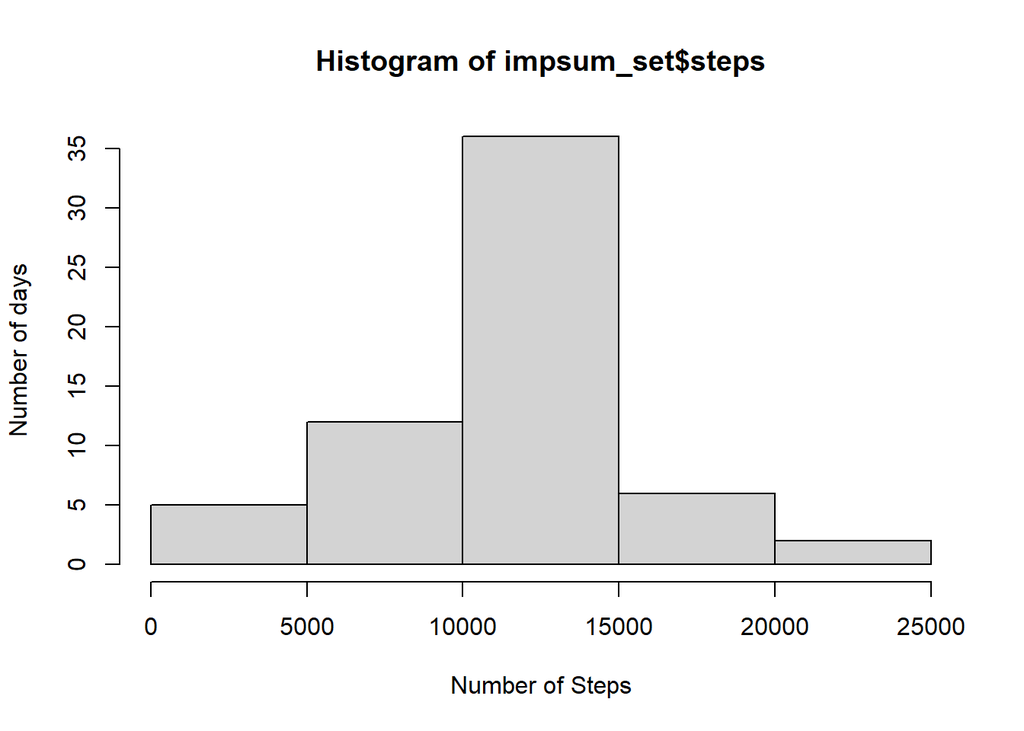

```r
hist(impsum_set$steps, xlab = "Number of Steps", ylab = "Number of days")
```

Calculate and report the mean and median total number of steps taken per day:

```r
## provides an overall summary of the dataset including the number of NAs
summary(impsum_set)
```

```
##       date                steps
##  Min.   :2012-10-01   Min.   :   41
##  1st Qu.:2012-10-16   1st Qu.: 9819
##  Median :2012-10-31   Median :10766
##  Mean   :2012-10-31   Mean   :10766
##  3rd Qu.:2012-11-15   3rd Qu.:12811
##  Max.   :2012-11-30   Max.   :21194
```

Do these values differ from the estimates from the first part of the assignment?

```r
## runs the summary of the non-imputed set for comparison
summary(sum_set)
```

```
##       date                steps
##  Min.   :2012-10-01   Min.   :   41
##  1st Qu.:2012-10-16   1st Qu.: 8841
##  Median :2012-10-31   Median :10765
##  Mean   :2012-10-31   Mean   :10766
##  3rd Qu.:2012-11-15   3rd Qu.:13294
##  Max.   :2012-11-30   Max.   :21194
##                       NA's   :8
```

```r
### adds a column with the day of week to the imputed set and a column that
### identifies whether or not it is a weekend
new_imputeset$weekday <- weekdays(new_imputeset$date)
new_imputeset <- cbind(new_imputeset,
                      daytype=ifelse(new_imputeset$weekday == "Saturday" |
                                     new_imputeset$weekday == "Sunday", "weekend"
                                     ,"weekday"))
```

Make a panel plot containing a time series plot of the 5-minute interval (x-axis) and the average number of steps taken, averaged across all weekday days or weekend days (y-axis). See the README file in the GitHub repository to see an example of what this plot should look like using simulated data.

```r
## creates two subsets, one for weekends and one for weekdays
weekend_set <- subset(new_imputeset, new_imputeset$daytype == "weekend")
weekday_set <- subset(new_imputeset, new_imputeset$daytype == "weekday")

## Summarizes each set into the average by interval
avg_weset <- weekend_set %>%
  group_by(interval) %>%
  summarise(steps = mean(steps, na.rm = TRUE))
avg_wdset <- weekday_set %>%
  group_by(interval) %>%
  summarise(steps = mean(steps, na.rm = TRUE))
```

[figure not shown]

```r
## creates a two panel plot
par(mfrow=c(2,1))
plot(avg_weset$interval,avg_weset$steps, type = "l", ylab="avg weekend steps",
     xlab = "interval")
plot(avg_wdset$interval,avg_weset$steps, type = "l", ylab="avg weekday steps",
     xlab = "interval")
```